# Assignment 6

In this assignment, you'll analyze a collection of data sets from the [San Francisco Open Data Portal](http://data.sfgov.org/) and [Zillow](https://www.zillow.com/). The data sets have been stored in the SQLite database `sf_data.sqlite`, which you can [download here](http://anson.ucdavis.edu/~nulle/sf_data.sqlite). The database contains the following tables:

| Table | Description |
| --- | --- |
| `crime` | Crime reports dating back to 2010. |
| `mobile_food_locations` | List of all locations where mobile food vendors sell. |
| `mobile_food_permits` | List of all mobile food vendor permits. More details [here](https://data.sfgov.org/api/views/rqzj-sfat/files/8g2f5RV4PEk0_b24iJEtgEet9gnh_eA27GlqoOjjK4k?download=true&filename=DPW_DataDictionary_Mobil… |
| `mobile_food_schedule` | Schedules for mobile food vendors. |
| `noise` | Noise complaints dating back to August 2015. |
| `parking` | List of all parking lots. |
| `parks` | List of all parks. |
| `schools` | List of all schools. |
| `zillow` | Zillow rent and housing statistics dating back to 1996. More details [here](https://www.zillow.com/research/data/). |

The `mobile_food_` tables are explicitly connected through the `locationid` and `permit` columns. The other tables are not connected, but you may be able to connect them using dates, latitude/longitude, or postal codes.

Shapefiles for US postal codes are available [here](https://www.census.gov/geo/maps-data/data/cbf/cbf_zcta.html). These may be useful for converting latitude/longitude to postal codes.

Shapefiles for San Francisco Neighborhoods are available [here](https://data.sfgov.org/Geographic-Locations-and-Boundaries/SF-Find-Neighborhoods/pty2-tcw4).

**Exercise 1.1.** Which mobile food vendor(s) sells at the most locations?

In this question, the food vendor moves from time to time and we can measure its movement by locationid. To get the mobile food vendor that sells at the most locations, we count the number of unique locationid by permit and then inner join the permit table to get permit's owner. Therefore, the mobile food vendor that sells at the most locations is May Catering's with permit 17MFF-0110.

```python
import sqlite3 as sql
import pandas as pd
import numpy as np
# !pip install folium
import folium
from folium.plugins import MarkerCluster, ScrollZoomToggler
from folium.plugins import HeatMap
import random
from collections import Counter
import os
import datetime
import gmaps
from matplotlib import pyplot as plt
%matplotlib notebook
import seaborn as sns
# conda install -c conda-forge geopandas
import geopandas as gpd
import shapely.geometry as geom
import statsmodels.formula.api as smf
gmaps.configure(api_key="AIzaSyDO_-IAFt6TrLVv9DAWMvW7CyCWDqMHrXo")
db = sql.connect("sf_data.sqlite")
```

```python
pd.read_sql("SELECT * FROM mobile_food_permits LIMIT 5", db)
```

|  | permit | Status | Applicant | FacilityType | FoodItems | PriorPermit | Approved | Expiration |
| --- | --- | --- | --- | --- | --- | --- | --- | --- |
| 0 | 16MFF-0027 | APPROVED | F & C Catering | Truck | Cold Truck: Hot/Cold Sandwiches: Water: Soda: ... | 1 | 2016-03-09 12:00:00 | 2017-03-15 12:00:00 |
| 1 | 13MFF-0102 | EXPIRED | Natan's Catering | Truck | Burgers: melts: hot dogs: burritos:sandwiches:... | 1 | 2013-04-12 12:00:00 | 2014-03-15 12:00:00 |
| 2 | 16MFF-0069 | APPROVED | Munch A Bunch | Truck | Cold Truck: packaged sandwiches: pitas: breakf... | 1 | 2016-03-15 12:00:00 | 2017-03-15 12:00:00 |
| 3 | 16MFF-0051 | APPROVED | Park's Catering | Truck | Cold Truck: Hamburger: cheeseburgers: hot dogs... | 1 | 2016-03-15 12:00:00 | 2017-03-15 12:00:00 |
| 4 | 16MFF-0010 | REQUESTED | Pipo's Grill | Truck | Tacos: Burritos: Hot Dogs: and Hamburgers | 0 | None | None |

```python
pd.read_sql("SELECT L.permit, R.Applicant, COUNT(DISTINCT(L.locationid)) AS Frequency FROM mobile_food_schedule AS 'L'"
            "INNER JOIN mobile_food_permits AS R ON L.permit = R.permit GROUP BY L.permit ORDER BY Frequency DESC LIMIT 5", db)
```

|  | permit | Applicant | Frequency |
| --- | --- | --- | --- |
| 0 | 17MFF-0110 | May Catering | 58 |
| 1 | 13MFF-0102 | Natan's Catering | 37 |
| 2 | 17MFF-0111 | Anas Goodies Catering | 37 |
| 3 | 17MFF-0090 | Liang Bai Ping | 33 |
| 4 | 16MFF-0051 | Park's Catering | 23 |

**Exercise 1.2.** Ask and use the database to analyze 5 questions about San Francisco. For each question, write at least 150 words and support your answer with plots. Make a map for at least 2 of the 5 questions.

You should try to come up with some questions on your own, but these are examples of reasonable questions:

- Which parts of the city are the most and least expensive?
- Which parts of the city are the most dangerous (and at what times)?
- Are noise complaints and mobile food vendors related?
- What are the best times and places to find food trucks?
- Is there a relationship between housing prices and any of the other tables?

Please make sure to clearly state each of your questions in your submission.

**Questions:**

**1. What time has the most frequent criminal cases? Plot the location to see where those cases are.**

In order to know which datetime has the most frequent criminal cases, I grouped the crime table by datetime and ordered by frequency. As we can see, every year's 01/01 00:01:00 is the most frequent time among the top frequent crimial cases' list, especially at 2011-01-01 00:01:00 with 185 cases.

```python
# Criminal cases group by time and order by frequency
pd.read_sql("SELECT *, COUNT(Datetime) AS Frequency FROM crime GROUP BY Datetime ORDER BY Frequency DESC LIMIT 5", db)
```

|  | IncidntNum | Category | Descript | DayOfWeek | Datetime | PdDistrict | Resolution | Address | Lon | Lat | Frequency |
| --- | --- | --- | --- | --- | --- | --- | --- | --- | --- | --- | --- |
| 0 | 140355202 | OTHER OFFENSES | FALSE PERSONATION TO RECEIVE MONEY OR PROPERTY | Saturday | 2011-01-01 00:01:00 | TARAVAL | NONE | 1300 Block of 24TH AV | -122.482347 | 37.762380 | 185 |
| 1 | 141081573 | NON-CRIMINAL | CASE CLOSURE | Friday | 2010-01-01 00:01:00 | RICHMOND | UNFOUNDED | 400 Block of 29TH AV | -122.489015 | 37.780842 | 150 |
| 2 | 130889465 | SEX OFFENSES, NON FORCIBLE | UNLAWFUL SEXUAL INTERCOURSE | Tuesday | 2013-01-01 00:01:00 | INGLESIDE | NONE | 300 Block of ELLINGTON AV | -122.446459 | 37.712349 | 103 |
| 3 | 120377577 | OTHER OFFENSES | FALSE PERSONATION | Sunday | 2012-01-01 00:01:00 | SOUTHERN | NONE | 0 Block of BAYSIDEVILLAGE PL | -122.389659 | 37.784881 | 94 |
| 4 | 150182716 | ASSAULT | BATTERY, FORMER SPOUSE OR DATING RELATIONSHIP | Thursday | 2015-01-01 00:01:00 | BAYVIEW | NONE | 1000 Block of SILVER AV | -122.414365 | 37.729425 | 84 |

```python
# Order the criminal frequency at specific time
frequent_case = pd.read_sql("SELECT *, COUNT(Category) AS count FROM crime WHERE Datetime = '2011-01-01 00:01:00'"
            "GROUP BY Category ORDER BY count DESC LIMIT 5" , db)
frequent_case
```

|  | IncidntNum | Category | Descript | DayOfWeek | Datetime | PdDistrict | Resolution | Address | Lon | Lat | count |
| --- | --- | --- | --- | --- | --- | --- | --- | --- | --- | --- | --- |
| 0 | 140355202 | OTHER OFFENSES | FALSE PERSONATION TO RECEIVE MONEY OR PROPERTY | Saturday | 2011-01-01 00:01:00 | TARAVAL | NONE | 1300 Block of 24TH AV | -122.482347 | 37.762380 | 75 |
| 1 | 130876371 | NON-CRIMINAL | COURTESY REPORT | Saturday | 2011-01-01 00:01:00 | CENTRAL | UNFOUNDED | 800 Block of PINE ST | -122.409804 | 37.790929 | 29 |
| 2 | 116001330 | LARCENY/THEFT | PETTY THEFT OF PROPERTY | Saturday | 2011-01-01 00:01:00 | SOUTHERN | NONE | 800 Block of BRYANT ST | -122.403405 | 37.775421 | 17 |
| 3 | 110042683 | ASSAULT | INFLICT INJURY ON COHABITEE | Saturday | 2011-01-01 00:01:00 | INGLESIDE | NONE | 3900 Block of MISSION ST | -122.426353 | 37.733847 | 13 |
| 4 | 110002530 | SUSPICIOUS OCC | INVESTIGATIVE DETENTION | Saturday | 2011-01-01 00:01:00 | INGLESIDE | NONE | 0 Block of SGTJOHNVYOUNG LN | -122.444707 | 37.724931 | 13 |

```python
# Plot the location of crimes by heatmap
frequent_location = frequent_case[['Lat', 'Lon']]
region = frequent_case['PdDistrict']
m = gmaps.Map()
heatmap_layer = gmaps.heatmap_layer(frequent_location, max_intensity=1, point_radius=20.0)
m.add_layer(heatmap_layer)
m
```

[output not shown]

**2. Which part of the city has the most criminal cases occured?**

The reason to use a choropleth map instead of a heat map for this question is that a choropleth map can color a specific region like district region; while a heat map can only put points in a specific location. I plotted 500 crime locations from the crime table, the aggregate number appears as a circle marker on the map. As you zoom in, the marker will split into to a smaller maker with a more precise number to represent the number of crimes in that area. Makers with large number appears in a darker region, this is once again consistent with the previous conclusion. Overall, the downtown area of San Francisco is the most dangerous region.

```python
# Load the crime table and convert to a dataframe with frequency of crime cases in each district
crime = pd.read_sql("SELECT * FROM crime", db)
# Calculate the total number of incidents per district
district = pd.DataFrame(Counter(crime['PdDistrict']).most_common())[:-1]
district.columns = ['District', 'Frequency']
district
```

|  | District | Frequency |
| --- | --- | --- |
| 0 | SOUTHERN | 196178 |
| 1 | MISSION | 136216 |
| 2 | NORTHERN | 124365 |
| 3 | CENTRAL | 109242 |
| 4 | BAYVIEW | 101655 |
| 5 | INGLESIDE | 89044 |
| 6 | TENDERLOIN | 84009 |
| 7 | TARAVAL | 75459 |
| 8 | PARK | 60974 |
| 9 | RICHMOND | 56258 |

```python
SF_COORDINATES = (37.76, -122.45)
# create empty map zoomed in on San Francisco
crime = crime.dropna(subset = ['Lat','Lon'])
districts = crime['PdDistrict']
# add a marker for every record in the filtered data, use a clustered view
# create empty map zoomed in on San Francisco
map = folium.Map(location=SF_COORDINATES, zoom_start=12)
locations = zip(crime['Lat'], crime['Lon'])
marker_cluster = folium.MarkerCluster("Cluster Name").add_to(map)
# add a marker for every record in the filtered data, use a clustered view
idx = random.sample(range(1, 1000000), 500)
for each in idx:
    folium.Marker(location = list(locations[each]), popup= districts[each]).add_to(map).add_to(marker_cluster)
sf = os.getcwd() + '\\sfpddistricts.geojson'
map.choropleth(geo_str = open(sf).read(), data = district,
    columns = ['District', 'Frequency'], key_on = 'feature.properties.DISTRICT', fill_color = 'YlOrRd',
              legend_name='Crime cases')
map
```

[interactive chart not shown]

```python
southern_cate = pd.DataFrame(Counter(crime[crime['PdDistrict'] == 'SOUTHERN']['Category']).most_common())[:10]
southern_cate.columns = ['category', 'frequency']
southern_cate
```

|  | category | frequency |
| --- | --- | --- |
| 0 | LARCENY/THEFT | 60068 |
| 1 | NON-CRIMINAL | 25576 |
| 2 | OTHER OFFENSES | 23811 |
| 3 | ASSAULT | 15114 |
| 4 | WARRANTS | 10347 |
| 5 | VANDALISM | 9048 |
| 6 | DRUG/NARCOTIC | 7917 |
| 7 | SUSPICIOUS OCC | 7063 |
| 8 | BURGLARY | 5779 |
| 9 | MISSING PERSON | 4866 |

**3. Are public schools and private schools distributed differently across the city?**

We can conclude that public schools and private schools distributed differently across the city, one reason to explain this circumstance would be the limiting education funding of the city. The city education department has a shortage of funding to run more public schools, while comparing to private school owners have more fiscal advantages to operate an educational organization.

```python
# Load the school table
schools = pd.read_sql("SELECT * FROM schools WHERE Entity = 'SFUSD' ", db)
data = zip(schools['Lat'],schools['Lon'])

m = folium.Map([37.76, -122.45], zoom_start=12)
# Plot the heatmap
HeatMap(data).add_to(m)
m.choropleth(
    geo_str = open(sf).read(),
    key_on = 'feature.properties.DISTRICT',
    fill_color = 'YlOrRd',
    fill_opacity = 0.0)
# Fix the map
toggler = ScrollZoomToggler().add_to(m)
m
```

[interactive chart not shown]

**4. What time has the most noise complains? Are noise complaints and mobile food vendors related?**

I firstly used the noise table to get the datetime and complaint frequency, and then plot the complaint frequency by time and day. From the plot we can see that the top number of complaints happens at Friday 22-23 and Saturday 22-24 o'colck. The possible interpretation is that people are having a party during the weekend. Another possible interpretation is that the owners are moving the mobile food vendors back to home, which may cause the noise.

In order to investigate if the noise complaints and mobile food vendors are related, I plotted the choropleth map of San Francisco city differentiated by the number of noise complaints. Regions with large number of noise complaints are in dark color, while regions with small number of noise complaints are in light color. Number of mobile food vendors in a specific region are clustered together. Dark red clusters indicate the large number of mobile food vendors in this region, while light green clusters indicate the small number of mobile food vendors in this region.

Intuitively, we may possess the idea that quiet places will have more mobile food vendors and noisy places will have less mobile food vendors, or vice versa. However, the map does not support either idea. Suppose that we want to know whether there is a negative relation between the noisiness of a neighborhood and the number of mobile food vendors. Under this assumption, we would like to see less mobile food vendors in noisier neighborhoods. From the map, we can observe that mobile food vendors are mainly distributed on the right wing of the city, and there are not many of them on the left wing. For the large number of mobile food vendors on the right wing, more are distributed closer to shore. That is, mobile food vendors are more distributed in neighborhoods like South of Market, Financial Districts, Potrero Hill, and Hunter's Point. These neighborhoods have a range of noise complaints from 78 to 241, which are not recognized as quiet places. The quietest neighborhoods, such as Sunset District, Richmond District and Lake Merced, have least number of mobile food vendors. Clearly, the map does not support this idea, and we conclude that noise complaints and mobile food vendors are not related.

Although not related to the noisiness of the neighborhood, the number of mobile food vendors is more likely related to the flow of people. Neighborhoods like South of Market and Financial District have huge flow of people, either people at work or tourists. Presumedly, it is these types of people that mobile food vendors target for.

```python
# Load the noise table and remove NAs
noise_time = pd.read_sql("SELECT Datetime FROM noise", db).dropna(subset = ['Datetime'])
date_time = pd.DataFrame([i.split(" ") for i in noise_time['Datetime']])
date_time.columns = ['date','time']

def day_of_week(date):
    '''
    Given a data and return a corresponding year, month and day
    Input:
        year-month-day
    Output:
        year, month, day (integer)
    '''
    year, month, day = (int(x) for x in date.split('-'))
    time = datetime.date(year, month, day)
    # Sunday is 0, Monday is 1
    time =  time.strftime("%w")
    return time

# Add the corresponding date, time, week
dayofweek = [int(day_of_week(i)) for i in date_time['date']]
date_time['dayofweek'] = dayofweek
date_time['time'] = [i.split(":")[0] for i in date_time['time']]
date_time = date_time.sort_values(by = 'dayofweek')
```

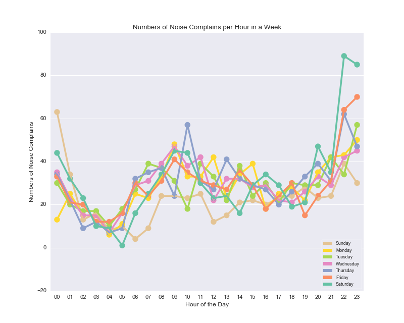

```python
# Set the figure size and color
plt.figure(figsize=(10,8))
spectrum = sns.color_palette("Set2",7)[::-1]

# Plot the number of complains by time and day
for i in range(7):
    a = date_time[date_time['dayofweek'] == i]
    b = pd.DataFrame.from_dict(dict(Counter(a['time'])),orient='index').reset_index().sort_values(by='index')
    b.columns = ['hour','freq']
    b.reset_index(drop = True)
    myplot = sns.pointplot(x = b.hour, y = b.freq, color = spectrum[i])

# Set label, title, legend of the figure
myplot.set(xlabel='Hour of the Day', ylabel='Numbers of Noise Complains',
           title = 'Numbers of Noise Complains per Hour in a Week')
mybar = [plt.Rectangle((0,0),1,1, fc=i, edgecolor = 'none') for i in spectrum]
g = plt.legend(mybar, ['Sunday','Monday','Tuesday','Wednesday','Thursday',"Friday","Saturday"],
               loc='lower right', ncol = 1, prop={'size':8})
g.draw_frame(True)
myplot
```

```python
def plotCounts(dataframe, xlabel_name, ylabel_name):

    sf_neighborhood = json.load(open(os.getcwd() + '/SanFrancisco.Neighborhoods.json'))
    neighborhoods = {str(feature[u'id']): str(feature[u'properties'][u'neighborhood'])
                     for feature in sf_neighborhood[u'features']}

    dataframe_groupby_zip = list(dataframe.groupby("zip"))
    dataframe_zips = [str(i[0]) for i in dataframe_groupby_zip]
    dataframe_zip_count = {dataframe_zips[i]: len(dataframe_groupby_zip[i][1])
                           for i in xrange(len(dataframe_groupby_zip))}
    dataframe_zip_count = pd.DataFrame.from_dict(dataframe_zip_count, orient = "index")
    dataframe_zip_count.columns = ["Count"]

    plt.figure(figsize = (10, 5), dpi = 100)

    colors = sns.color_palette("YlOrRd", len(dataframe_zip_count))
    colors = colors[::-1]

    plot_dataframe_count = sns.barplot(x = dataframe_zip_count.index,
                                       y = dataframe_zip_count.Count, palette = colors,
                                       order = list(dataframe_zip_count.sort_values(by = "Count",
                                                                                    ascending = False).index))
    for tick in plot_dataframe_count.get_xticklabels():
        tick.set_rotation(-45)

    plot_dataframe_count.set(xlabel = "{}".format(xlabel_name), ylabel = "Number of {}".format(ylabel_name),
                         title = "Number of {} by {}".format(ylabel_name, xlabel_name))

    return plot_dataframe_count
```

```python
# Load all needed tables
noise_df = pd.read_sql("SELECT * FROM noise", db)
mobile_food_locations_df = pd.read_sql("SELECT * FROM mobile_food_locations", db)
noise_df = noise_df.dropna()
noise_df = noise_df.reset_index(drop = True)
noise_type_count = pd.read_sql("SELECT COUNT(Type) AS 'TypeCount', Neighborhood FROM noise GROUP BY Neighborhood", db)[1:]
mobile_food_locations = zip(mobile_food_locations_df["Latitude"], mobile_food_locations_df["Longitude"])
schools_df = pd.read_sql("SELECT * FROM schools", db)
zillow_df = pd.read_sql("SELECT * FROM zillow", db)
```

```python
# Plot the choropleth map for San Francisco.
SF_COORDINATES = (37.76, -122.45)
sf = os.getcwd() + '/SF.Neighborhoods.json'
# Create a San Francisco map.
m = folium.Map(SF_COORDINATES, zoom_start = 13)

marker_cluster = folium.MarkerCluster("Cluster Name").add_to(m)
for loc in mobile_food_locations:
    folium.Marker(location = list(loc)).add_to(m).add_to(marker_cluster)

m.choropleth(
    geo_str = open(sf).read(),
    data = noise_type_count,
    columns = ['Neighborhood', 'TypeCount'],
    key_on = 'feature.properties.neighborhood',
    fill_color = 'BuPu',
    fill_opacity = 0.85,
    line_weight = 1.2,
    legend_name = "Number of Noise Complaints in the Neighborhood"
)

# Add a toggler to disable zooming.
toggler = ScrollZoomToggler().add_to(m)
m
```

[interactive chart not shown]

**5. Is the number of schools positively correlated to the housing price in a certain neighborhood?**

For this question, if the assumption holds, we will see more schools in an expensive neighborhood compared to the number of schools in an inexpensive neighborhood. However, this is not entirely true. Consider the moderately dark blue regions in the middle of the map. Those neighborhoods are Twin Peaks, Noe Valley and The Castro, respectively. The clusters representing the number of schools in the neighborhood are green, which indicates the number of schools is relatively low. However, in neighborhoods such as Sunset District, Richmond District and Lake Merced, some clusters are yellow, indicating a moderately high number of schools in the neighborhood. Despite this observation, neighborhoods like Pacific Heights and Nob Hill, where median house sold price is in the range from 565 to 637, are concerntrated with more schools. In short, the statement that more schools exist in more expensive neighborhoods holds partially correct.

From the discussion above, we conclude that the statement holds true in some neighborhoods, while not true in other neighborhoods. A more general statement involving the number of schools and the housing price would be: the number of schools depends on the number of local residents in that neighborhood. While some neighborhood are more expensive regarding the housing price, the housing price is determined by the market.

```python
school_locations = zip(schools_df["Lat"], schools_df["Lon"])
# Create a San Francisco map.
m = folium.Map(SF_COORDINATES, zoom_start = 13, control_scale = False)

marker_cluster = folium.MarkerCluster("Cluster Name").add_to(m)
for loc in school_locations:
    folium.Marker(location = list(loc)).add_to(m).add_to(marker_cluster)

m.choropleth(
    geo_str = open(sf).read(),
    data = zillow_df,
    columns = ['RegionName', 'MedianSoldPricePerSqft_AllHomes'],
    key_on = 'feature.properties.id',
    fill_color = 'YlGnBu',
    fill_opacity = 0.75,
    line_weight = 1.2,
    legend_name = "Median Sold Price per Sqft"
)

# Add a toggler to disable zooming.
toggler = ScrollZoomToggler().add_to(m)
m
```

[interactive chart not shown]